# Imputación de datos faltantes

## Patrones

Los patrones de datos faltantes representan relaciones matemáticas genéricas entre los datos observados y los ausentes.

## Clasificación de los datos perdidos

Rubin1 clasificó los problemas de datos faltantes en tres categorías. En su teoría, cada dato tiene alguna probabilidad de faltar. El proceso que gobierna estas probabilidades se denomina mecanismo de datos faltantes o mecanismo de respuesta. El modelo del proceso se denomina modelo de datos faltantes o modelo de respuesta.

- **MCAR (Missing Completely At Random):** La probabilidad de que una respuesta a una variable sea dato faltante es independiente tanto del valor de esta variable como del valor de otras variables del conjunto de datos.En términos más simples, la ausencia de datos ocurre aleatoriamente, sin un patrón discernible. Un ejemplo clásico de MCAR es cuando un participante de una encuesta omite una pregunta involuntariamente . La probabilidad de que falten datos es independiente de la información presente en el conjunto de datos.
- **MAR (Missing At Random):** La probabilidad de que una respuesta sea dato faltante es independiente de los valores de la misma variable pero es dependiente de los valores de otras variables del conjunto de datos.Por ejemplo, en una encuesta, la falta de respuestas a preguntas sobre ingresos podría estar relacionada con la ocupación o el nivel educativo de los encuestados, pero no con sus propios ingresos. MAR es más general y más realista que MCAR.
- **NMAR (Not Missing At Random):** Si ni MCAR ni MAR se cumplen, entonces hablamos de datos perdidos no al azar (MNAR). MNAR significa que la probabilidad de existencia de NAs varía por razones que desconocemos: siguen un patrón. Por ejemplo, el mecanismo de una balanza puede desgastarse con el tiempo, produciendo más datos faltantes a medida que avanza el tiempo, pero es posible que éste proceso sea tan lento que resulte imperceptible. Si los objetos más pesados se miden más tarde en el tiempo, obtenemos una distribución de las medidas que se distorsionará. MNAR incluye la posibilidad de que la escala produzca más valores perdidos para los objetos más pesados

Como ejemplo utilizamos una base de datos **airquality** (calidad del aire) que se encuentra en R.

```r
base <- airquality
head(base)
```

|  | Ozone | Solar.R | Wind | Temp | Month | Day |
| --- | --- | --- | --- | --- | --- | --- |
| 1 | 41 | 190 | 7.4 | 67 | 5 | 1 |
| 2 | 36 | 118 | 8.0 | 72 | 5 | 2 |
| 3 | 12 | 149 | 12.6 | 74 | 5 | 3 |
| 4 | 18 | 313 | 11.5 | 62 | 5 | 4 |
| 5 | NA | NA | 14.3 | 56 | 5 | 5 |
| 6 | 28 | NA | 14.9 | 66 | 5 | 6 |

Una de las posibles librerías para las imputación datos faltantes es es **VIM**

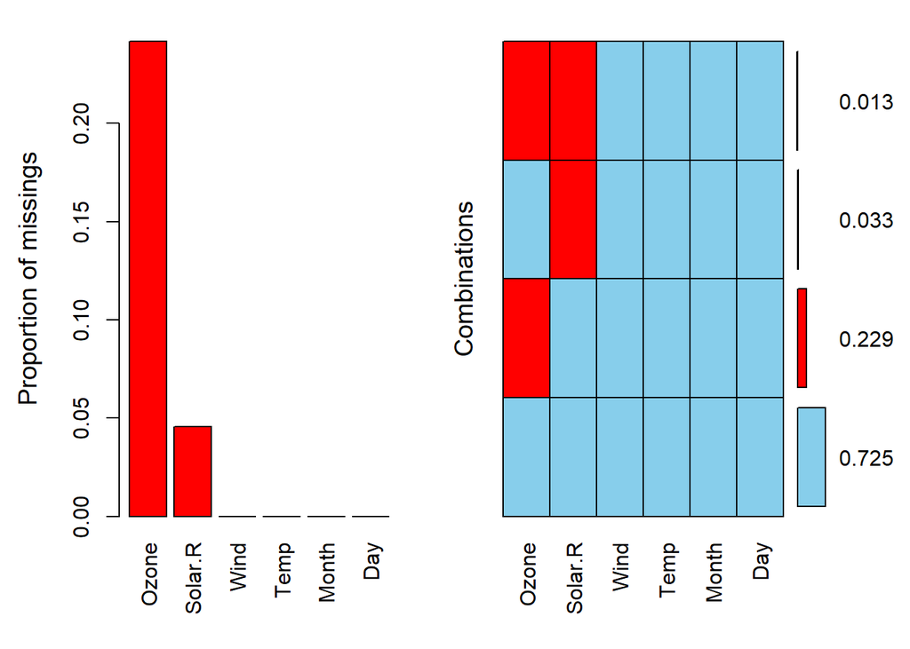

```
##
##  Variables sorted by number of missings:
##  Variable      Count
##     Ozone 0.24183007
##   Solar.R 0.04575163
##      Wind 0.00000000
##      Temp 0.00000000
##     Month 0.00000000
##       Day 0.00000000
```

```r
#install.packages("VIM")
library(VIM)

aggr(base,numbers=T,sortVar=T)
```

## Imputando NAs

El concepto imputación tiene cierta relación con su acepción legal: significa un dato cuestionable (pues no existe) y se lo castiga eliminándolo.

### Imputación con la media (Mean imputation)

Una solución rápida para el problema de los NA es reemplazarlos por la media. Podemos usar la “moda” para datos categóricos. Suponga que queremos imputar la media en Ozono y Solar.R de los datos de calidad del aire. Utilizamos el paquete mice.

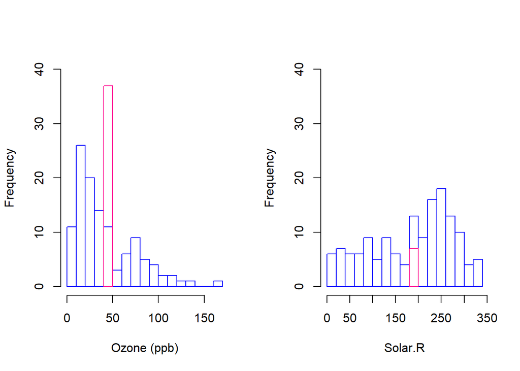

```r
library(mice)

columnas <- c("Ozone", "Solar.R")
imput_data <- mice(base[,names(base) %in% columnas],m = 1,
  maxit = 1, method = "mean", print=F)
complete.data <- complete(imput_data)

par(mfrow = c(1, 2))

hist(na.omit(airquality$Ozone),
     breaks = 15,
     col = NA,
     border = "blue",
     ylim = c(0, 40),
     xlab = "Ozone (ppb)",
     ylab = "Frequency",
     main = "")

hist(complete.data$Ozone[which(is.na(airquality$Ozone))],
     col = NA,
     border = "deeppink",
     add = TRUE)

hist(na.omit(airquality$Solar.R),
     breaks = 15,
     col = NA,
     border = "blue",
     ylim = c(0, 40),
     xlab = "Solar.R",
     ylab = "Frequency",
     main = "")

hist(complete.data$Solar.R[which(is.na(airquality$Solar.R))],
     col = NA,
     border = "deeppink",
     add = TRUE)
```

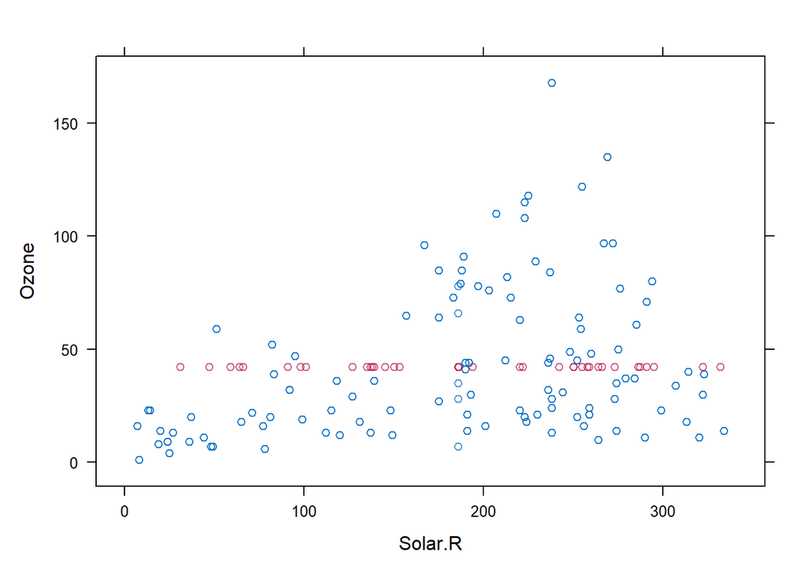

```r
xyplot(imput_data,Ozone ~ Solar.R)
```

La imputación media subestimará la varianza, alterará las relaciones entre las variables, sesgará casi cualquier estimación que no sea la media y sesgará la estimación de la media cuando los datos no sean MCAR.

### Imputación de regresión (Regression imputation)

La imputación de regresión incorpora el conocimiento de otras variables con la idea de producir imputaciones más inteligentes. El primer paso consiste en construir un modelo a partir de los datos observados. Las predicciones para los casos incompletos se calculan luego bajo el modelo ajustado y sirven como reemplazos para los datos faltantes. Suponga que predecimos el ozono por regresión lineal sobre Solar.R.

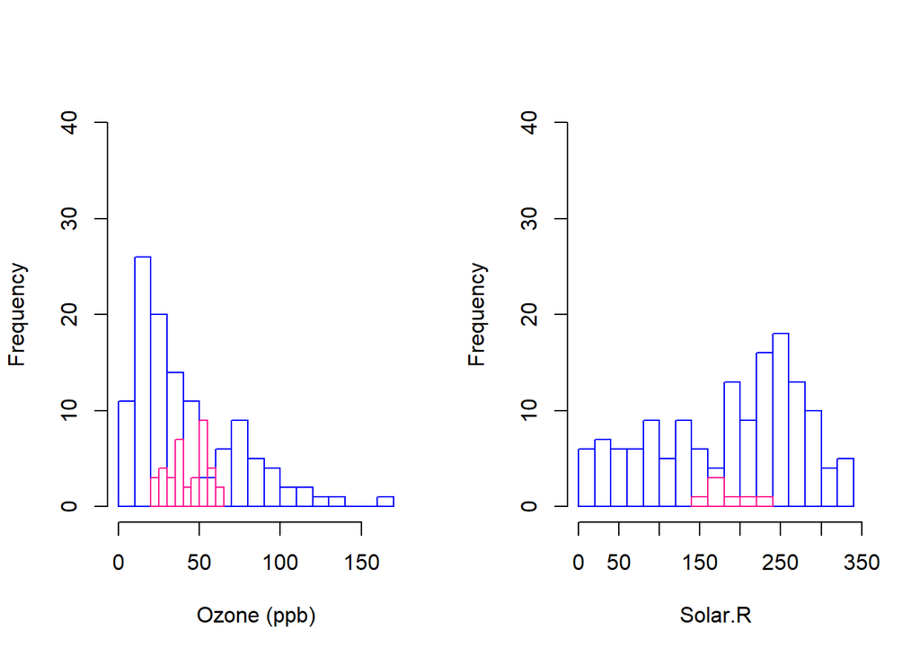

```r
library(mice)

columnas <- c("Ozone", "Solar.R")
imput_data1 <- mice(base[,names(base) %in% columnas],m = 1,
  maxit = 1, method = "norm.predict", seed = 2018,print=F)
complete.data1 <- complete(imput_data1)

par(mfrow = c(1, 2))

hist(na.omit(airquality$Ozone),
     breaks = 15,
     col = NA,
     border = "blue",
     ylim = c(0, 40),
     xlab = "Ozone (ppb)",
     ylab = "Frequency",
     main = "")

hist(complete.data1$Ozone[which(is.na(airquality$Ozone))],
     col = NA,
     border = "deeppink",
     add = TRUE)


hist(na.omit(airquality$Solar.R),
     breaks = 15,
     col = NA,
     border = "blue",
     ylim = c(0, 40),
     xlab = "Solar.R",
     ylab = "Frequency",
     main = "")

hist(complete.data1$Solar.R[which(is.na(airquality$Solar.R))],
     col = NA,
     border = "deeppink",
     add = TRUE)
```

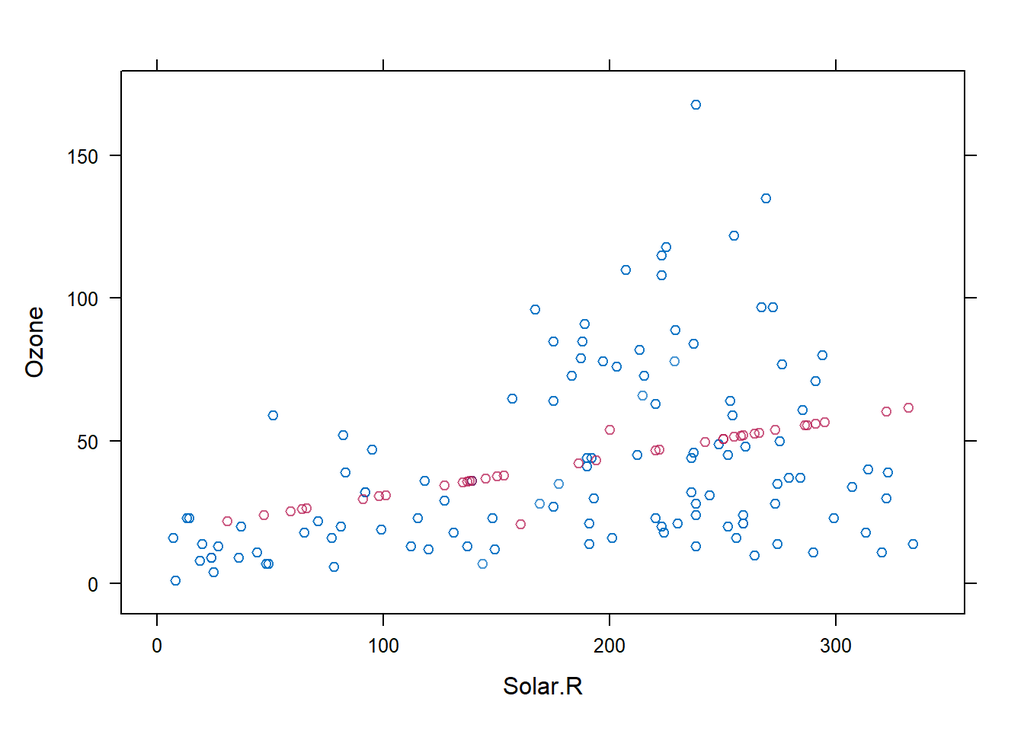

```r
xyplot(imput_data1,Ozone ~ Solar.R)
```

### Imputación de regresión estocástica (Stochastic regression imputation)

La imputación de regresión estocástica es un refinamiento de los intentos de imputación de regresión para abordar el sesgo de correlación agregando ruido a las predicciones. El siguiente código imputa Ozone de Solar.R mediante imputación de regresión estocástica.

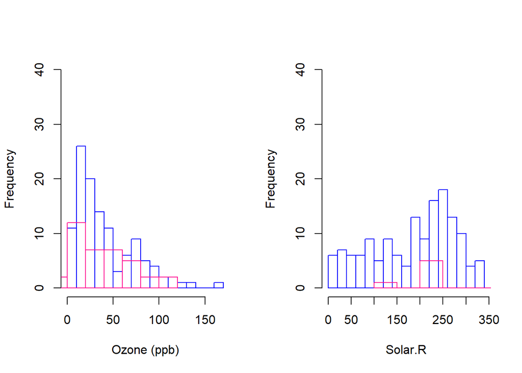

```r
imput_data2 <- mice(base[,names(base) %in% columnas],m = 1,
  maxit = 1, method = "norm.nob", seed = 2018,print=F)
complete.data2 <- complete(imput_data2)

par(mfrow = c(1, 2))

hist(na.omit(airquality$Ozone),
     breaks = 15,
     col = NA,
     border = "blue",
     ylim = c(0, 40),
     xlab = "Ozone (ppb)",
     ylab = "Frequency",
     main = "")

hist(complete.data2$Ozone[which(is.na(airquality$Ozone))],
     col = NA,
     border = "deeppink",
     add = TRUE)

hist(na.omit(airquality$Solar.R),
     breaks = 15,
     col = NA,
     border = "blue",
     ylim = c(0, 40),
     xlab = "Solar.R",
     ylab = "Frequency",
     main = "")

hist(complete.data2$Solar.R[which(is.na(airquality$Solar.R))],
     col = NA,
     border = "deeppink",
     add = TRUE)
```

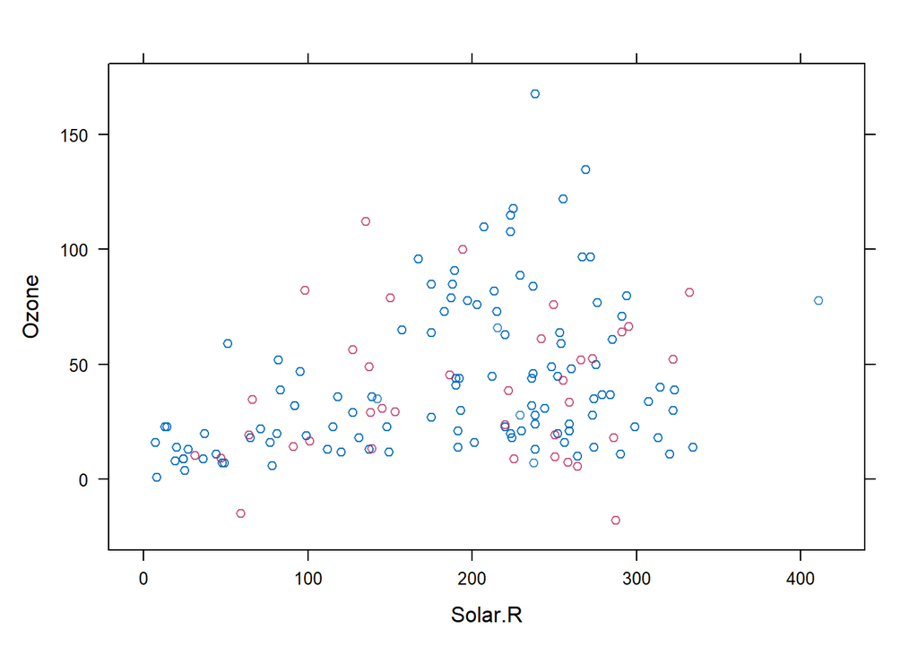

```r
xyplot(imput_data2, Ozone ~ Solar.R)
```

### LOCF y BOCF

La última observación trasladada (LOCF) y la observación de la línea de base trasladada (BOCF) son métodos de imputación ad-hoc para datos longitudinales. La idea es tomar el valor observado anteriormente como reemplazo de los datos faltantes. Cuando faltan varios valores seguidos, el método busca el último valor observado.

La función fill() del paquete tidyr aplica LOCF completando el último valor conocido. Esto es útil en situaciones en las que los valores se registran solo cuando cambian, como en los datos de tiempo transcurrido hasta el evento. Por ejemplo, podemos usar LOCF para completar el ozono con:

```r
library(tidyr)

imputar <- fill(airquality, Ozone)
imputar
```

| Ozone | Solar.R | Wind | Temp | Month | Day |
| --- | --- | --- | --- | --- | --- |
| 41 | 190 | 7.4 | 67 | 5 | 1 |
| 36 | 118 | 8.0 | 72 | 5 | 2 |
| 12 | 149 | 12.6 | 74 | 5 | 3 |
| 18 | 313 | 11.5 | 62 | 5 | 4 |
| 18 | NA | 14.3 | 56 | 5 | 5 |
| 28 | NA | 14.9 | 66 | 5 | 6 |
| 23 | 299 | 8.6 | 65 | 5 | 7 |
| 19 | 99 | 13.8 | 59 | 5 | 8 |
| 8 | 19 | 20.1 | 61 | 5 | 9 |
| 8 | 194 | 8.6 | 69 | 5 | 10 |

[output cut: 143 more lines]

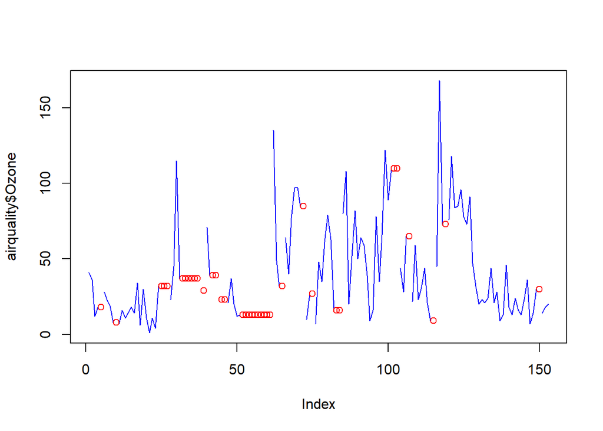

```r
imputar$categoria <- NA
imputar$categoria[which(is.na(airquality$Ozone))] <- imputar$Ozone[which(is.na(airquality$Ozone))]

plot(airquality$Ozone, type = "l", col ="blue")
points(imputar$categoria, col ="red")
```

### Imputación múltiple

La imputación múltiple crea $m>1$ conjuntos de datos completos. Cada uno de estos conjuntos de datos se analiza mediante un software de análisis estándar. Los m resultados se agrupan en una estimación puntual final más un error estándar al agrupar basado en las reglas (“reglas de Rubin”). La Figura ilustra los tres pasos principales en la imputación múltiple: imputación, análisis y agrupación.

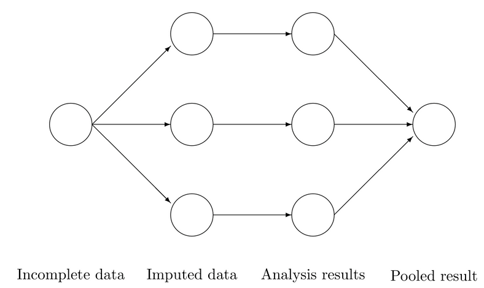

- Pasos:
1. El análisis comienza con datos observados e incompletos. La imputación múltiple crea varias versiones completas de los datos reemplazando los valores faltantes por valores de datos plausibles. Estos valores plausibles se extraen de una distribución modelada específicamente para cada entrada faltante. La figura muestra m = 3 conjuntos de datos imputados. En la práctica, m se suele tomar más grande. El número m = 3 se toma aquí sólo para señalar que la técnica crea múltiples versiones de los datos imputados. Los tres conjuntos de datos imputados son idénticos para las entradas de datos observados, pero difieren en los valores imputados. La magnitud de éstas diferencias refleja nuestra incertidumbre sobre qué valor imputar.
2. El segundo paso es estimar los parámetros de interés de cada conjunto de datos imputados. Por lo general, esto se hace aplicando el método analítico que hubiéramos utilizado si los datos estuvieran estado completos. Los resultados serán diferentes porque sus datos de entrada son diferentes. Es importante darse cuenta de que estas diferencias se deben únicamente a la incertidumbre sobre qué valor imputar.
3. El último paso es agrupar las estimaciones del parámetro m en una sola estimación y estimar su varianza. La varianza combina la varianza de muestreo convencional (varianza dentro de la imputación) y la varianza adicional causada por los datos faltantes (varianza entre imputación). En las condiciones adecuadas, las estimaciones agrupadas son insesgadas y tienen las propiedades estadísticas correctas.

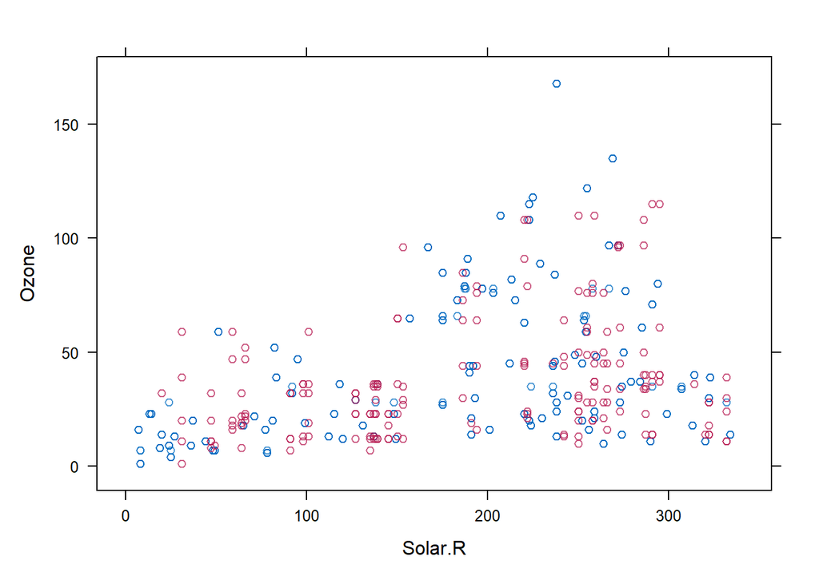

```r
imputed_data3 <- mice(base[,names(base) %in% columnas], seed=2018, print = F, m = 5)
complete.data3 <- complete(imputed_data3)

xyplot(imputed_data3,Ozone ~ Solar.R)
```

## Ejercicio

Importar la base **Properati Properati (USD) con NA**. Imputar los datos faltantes con los diferentes métodos. Una vez imputados los datos, comparar tales resultados con los valores reales, que se encuentran en la base **Properati Properati (USD)**. Esta comparación se pude realizar calculando alguna medida de bondad de ajuste, como puede ser:

$ECM=\frac{\sum_{i=1}^{n}(imputado_i - real_i)^2}{n}$

1(1978). Multiple imputations in sample surveys. A phenomenological bayesian approach to nonresponse. Proceedings of the Survey Research Methods Section, American Statistical Association. 20–34

- Referencia

https://stefvanbuuren.name/fimd/ https://rpubs.com/dataintelligence/reemplazo_de_NAs